# Confusion Matrix & ROC

Abhinav Reddy

2024-02-25

- This below R code will load the necessary libraries, load the “Default” dataset, and displays summary of the dataset.

```r
library(class)
library(caret)
library(ISLR)
summary(Default)
```

```
##  default    student       balance           income
##  No :9667   No :7056   Min.   :   0.0   Min.   :  772
##  Yes: 333   Yes:2944   1st Qu.: 481.7   1st Qu.:21340
##                        Median : 823.6   Median :34553
##                        Mean   : 835.4   Mean   :33517
##                        3rd Qu.:1166.3   3rd Qu.:43808
##                        Max.   :2654.3   Max.   :73554
```

- This below code normalizes the “Default” dataset using the “range” method, creating a normalization model and applying it to the dataset to transform the variables to a specified range.

```r
normalize_mod <- preProcess(Default, method = c('range'))

Def_normalize <- predict(normalize_mod, Default)
```

- This below R code removes the second variable (student status) from the normalized “Default” dataset.

```r
Def_normalize <- Def_normalize[, -2]
```

- This below R code splits the normalized dataset into training and testing sets, ensuring that 80% of the data is used for training and the remaining 20% for testing. This division facilitates model training and evaluation.

```r
Index_Trn <- createDataPartition(Def_normalize$default, p = 0.8, list = FALSE)
Train <- Def_normalize[Index_Trn, ]
Test <- Def_normalize[-Index_Trn, ]
```

- This below R code extracts predictor variables (2nd and 3rd columns) and labels (1st column) from both the training and testing datasets, preparing them for use in model training and evaluation.

```r
Train_Predictor <- Train[,2:3]
Test_Predictor <- Test[, 2:3]


Train_lbls <- Train[, 1]
Test_lbls <- Test[, 1]
```

- This below R code uses the k-nearest neighbors (KNN) algorithm with k=4 to predict labels for the testing data based on the training data. The predicted labels are stored in Predicted_Test_lbls.

```r
Predicted_Test_lbls <- knn(train = Train_Predictor,
                             test = Test_Predictor,
                             cl = Train_lbls,
                             k = 4)
```

- This function displays the first few values:

```r
head(Predicted_Test_lbls)
```

```
## [1] No No No No No No
## Levels: No Yes
```

- This below R code generates a confusion matrix to evaluate the performance of the model by comparing predicted labels with actual labels.

```r
library(caret)

# Create confusion matrix
confusion_matrix <- confusionMatrix(data = Predicted_Test_lbls, reference = Test_lbls)

confusion_matrix
```

```
## Confusion Matrix and Statistics
##
##           Reference
## Prediction   No  Yes
##        No  1915   43
##        Yes   18   23
##
##                Accuracy : 0.9695
##                  95% CI : (0.961, 0.9766)
##     No Information Rate : 0.967
##     P-Value [Acc > NIR] : 0.29120
##
##                   Kappa : 0.4151
##
##  Mcnemar's Test P-Value : 0.00212
##
##             Sensitivity : 0.9907
##             Specificity : 0.3485
##          Pos Pred Value : 0.9780
##          Neg Pred Value : 0.5610
##              Prevalence : 0.9670
##          Detection Rate : 0.9580
##    Detection Prevalence : 0.9795
##       Balanced Accuracy : 0.6696
##
##        'Positive' Class : No
##
```

# Plotting an ROC Curve

```r
library(pROC)
```

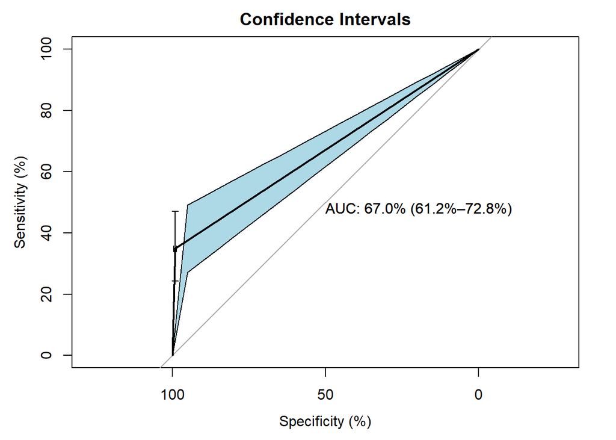

```r
roc <- plot.roc(as.numeric(Test$default),as.numeric(Predicted_Test_lbls),

                   main = "Confidence Intervals",
                   percent=TRUE,
                   ci = TRUE,
                   print.auc = TRUE)
ciobj <- ci.se(roc,
               specificities = seq(0, 100, 5))
plot(ciobj, type = "shape", col = "lightblue")
plot(ci(roc, of = "thresholds", thresholds = "best"))
```